# Risk Factor Analysis

## Outcome Variable

**Outcome Variable:** stunted

## Predictor Variables

**Intervention Variable:** mbmi

**Adjustment Set:**

- arm
- W_mage
- W_fage
- meducyrs
- feducyrs
- single
- brthmon
- delta_W_mage
- delta_W_fage
- delta_meducyrs
- delta_feducyrs
- delta_single
- delta_brthmon

## Stratifying Variables

The analysis was stratified on these variable(s):

- agecat
- studyid
- country

## Data Summary

| agecat | studyid | country | mbmi | stunted | n_cell | n |
| --- | --- | --- | --- | --- | --- | --- |
| Birth | ki0047075b-MAL-ED | BANGLADESH | Normal weight | 0 | 130 | 246 |
| Birth | ki0047075b-MAL-ED | BANGLADESH | Normal weight | 1 | 28 | 246 |
| Birth | ki0047075b-MAL-ED | BANGLADESH | Underweight | 0 | 25 | 246 |
| Birth | ki0047075b-MAL-ED | BANGLADESH | Underweight | 1 | 5 | 246 |
| Birth | ki0047075b-MAL-ED | BANGLADESH | Overweight or Obese | 0 | 49 | 246 |
| Birth | ki0047075b-MAL-ED | BANGLADESH | Overweight or Obese | 1 | 9 | 246 |
| Birth | ki0047075b-MAL-ED | BRAZIL | Normal weight | 0 | 62 | 184 |
| Birth | ki0047075b-MAL-ED | BRAZIL | Normal weight | 1 | 8 | 184 |
| Birth | ki0047075b-MAL-ED | BRAZIL | Underweight | 0 | 7 | 184 |
| Birth | ki0047075b-MAL-ED | BRAZIL | Underweight | 1 | 2 | 184 |
| Birth | ki0047075b-MAL-ED | BRAZIL | Overweight or Obese | 0 | 96 | 184 |
| Birth | ki0047075b-MAL-ED | BRAZIL | Overweight or Obese | 1 | 9 | 184 |
| Birth | ki0047075b-MAL-ED | INDIA | Normal weight | 0 | 96 | 198 |
| Birth | ki0047075b-MAL-ED | INDIA | Normal weight | 1 | 21 | 198 |
| Birth | ki0047075b-MAL-ED | INDIA | Underweight | 0 | 32 | 198 |
| Birth | ki0047075b-MAL-ED | INDIA | Underweight | 1 | 7 | 198 |
| Birth | ki0047075b-MAL-ED | INDIA | Overweight or Obese | 0 | 38 | 198 |
| Birth | ki0047075b-MAL-ED | INDIA | Overweight or Obese | 1 | 4 | 198 |
| Birth | ki0047075b-MAL-ED | NEPAL | Normal weight | 0 | 88 | 172 |
| Birth | ki0047075b-MAL-ED | NEPAL | Normal weight | 1 | 11 | 172 |
| Birth | ki0047075b-MAL-ED | NEPAL | Underweight | 0 | 0 | 172 |
| Birth | ki0047075b-MAL-ED | NEPAL | Underweight | 1 | 0 | 172 |
| Birth | ki0047075b-MAL-ED | NEPAL | Overweight or Obese | 0 | 66 | 172 |
| Birth | ki0047075b-MAL-ED | NEPAL | Overweight or Obese | 1 | 7 | 172 |
| Birth | ki0047075b-MAL-ED | PERU | Normal weight | 0 | 130 | 276 |
| Birth | ki0047075b-MAL-ED | PERU | Normal weight | 1 | 19 | 276 |
| Birth | ki0047075b-MAL-ED | PERU | Underweight | 0 | 3 | 276 |
| Birth | ki0047075b-MAL-ED | PERU | Underweight | 1 | 2 | 276 |
| Birth | ki0047075b-MAL-ED | PERU | Overweight or Obese | 0 | 110 | 276 |
| Birth | ki0047075b-MAL-ED | PERU | Overweight or Obese | 1 | 12 | 276 |

[output cut: 216 more lines]

The following strata were considered:

- agecat: 24 months, studyid: ki0047075b-MAL-ED, country: BANGLADESH
- agecat: 24 months, studyid: ki0047075b-MAL-ED, country: BRAZIL
- agecat: 24 months, studyid: ki0047075b-MAL-ED, country: INDIA
- agecat: 24 months, studyid: ki0047075b-MAL-ED, country: NEPAL
- agecat: 24 months, studyid: ki0047075b-MAL-ED, country: PERU
- agecat: 24 months, studyid: ki0047075b-MAL-ED, country: SOUTH AFRICA
- agecat: 24 months, studyid: ki0047075b-MAL-ED, country: TANZANIA, UNITED REPUBLIC OF
- agecat: 24 months, studyid: ki1017093-NIH-Birth, country: BANGLADESH
- agecat: 24 months, studyid: ki1017093b-PROVIDE, country: BANGLADESH
- agecat: 24 months, studyid: ki1017093c-NIH-Crypto, country: BANGLADESH
- agecat: 24 months, studyid: ki1066203-TanzaniaChild2, country: TANZANIA, UNITED REPUBLIC OF
- agecat: 24 months, studyid: ki1119695-PROBIT, country: BELARUS
- agecat: 24 months, studyid: ki1126311-ZVITAMBO, country: ZIMBABWE
- agecat: 24 months, studyid: ki1148112-LCNI-5, country: MALAWI
- agecat: 6 months, studyid: ki0047075b-MAL-ED, country: BANGLADESH
- agecat: 6 months, studyid: ki0047075b-MAL-ED, country: BRAZIL
- agecat: 6 months, studyid: ki0047075b-MAL-ED, country: INDIA
- agecat: 6 months, studyid: ki0047075b-MAL-ED, country: NEPAL
- agecat: 6 months, studyid: ki0047075b-MAL-ED, country: PERU
- agecat: 6 months, studyid: ki0047075b-MAL-ED, country: SOUTH AFRICA
- agecat: 6 months, studyid: ki0047075b-MAL-ED, country: TANZANIA, UNITED REPUBLIC OF
- agecat: 6 months, studyid: ki1000304b-SAS-CompFeed, country: INDIA
- agecat: 6 months, studyid: ki1017093-NIH-Birth, country: BANGLADESH
- agecat: 6 months, studyid: ki1017093b-PROVIDE, country: BANGLADESH
- agecat: 6 months, studyid: ki1017093c-NIH-Crypto, country: BANGLADESH
- agecat: 6 months, studyid: ki1066203-TanzaniaChild2, country: TANZANIA, UNITED REPUBLIC OF
- agecat: 6 months, studyid: ki1119695-PROBIT, country: BELARUS
- agecat: 6 months, studyid: ki1126311-ZVITAMBO, country: ZIMBABWE
- agecat: 6 months, studyid: ki1148112-LCNI-5, country: MALAWI
- agecat: Birth, studyid: ki0047075b-MAL-ED, country: BANGLADESH
- agecat: Birth, studyid: ki0047075b-MAL-ED, country: BRAZIL
- agecat: Birth, studyid: ki0047075b-MAL-ED, country: INDIA
- agecat: Birth, studyid: ki0047075b-MAL-ED, country: NEPAL
- agecat: Birth, studyid: ki0047075b-MAL-ED, country: PERU
- agecat: Birth, studyid: ki0047075b-MAL-ED, country: SOUTH AFRICA
- agecat: Birth, studyid: ki0047075b-MAL-ED, country: TANZANIA, UNITED REPUBLIC OF
- agecat: Birth, studyid: ki1000304b-SAS-CompFeed, country: INDIA
- agecat: Birth, studyid: ki1017093-NIH-Birth, country: BANGLADESH
- agecat: Birth, studyid: ki1017093c-NIH-Crypto, country: BANGLADESH
- agecat: Birth, studyid: ki1119695-PROBIT, country: BELARUS
- agecat: Birth, studyid: ki1126311-ZVITAMBO, country: ZIMBABWE

### Dropped Strata

Some strata were dropped due to rare outcomes:

- agecat: Birth, studyid: ki0047075b-MAL-ED, country: BRAZIL
- agecat: Birth, studyid: ki0047075b-MAL-ED, country: INDIA
- agecat: Birth, studyid: ki0047075b-MAL-ED, country: NEPAL
- agecat: Birth, studyid: ki0047075b-MAL-ED, country: PERU
- agecat: Birth, studyid: ki0047075b-MAL-ED, country: SOUTH AFRICA
- agecat: Birth, studyid: ki0047075b-MAL-ED, country: TANZANIA, UNITED REPUBLIC OF
- agecat: Birth, studyid: ki1000304b-SAS-CompFeed, country: INDIA
- agecat: Birth, studyid: ki1017093-NIH-Birth, country: BANGLADESH
- agecat: Birth, studyid: ki1017093c-NIH-Crypto, country: BANGLADESH
- agecat: Birth, studyid: ki1119695-PROBIT, country: BELARUS
- agecat: 6 months, studyid: ki0047075b-MAL-ED, country: BRAZIL
- agecat: 6 months, studyid: ki0047075b-MAL-ED, country: NEPAL
- agecat: 6 months, studyid: ki0047075b-MAL-ED, country: PERU
- agecat: 6 months, studyid: ki0047075b-MAL-ED, country: SOUTH AFRICA
- agecat: 6 months, studyid: ki0047075b-MAL-ED, country: TANZANIA, UNITED REPUBLIC OF
- agecat: 6 months, studyid: ki1066203-TanzaniaChild2, country: TANZANIA, UNITED REPUBLIC OF
- agecat: 24 months, studyid: ki0047075b-MAL-ED, country: BRAZIL
- agecat: 24 months, studyid: ki0047075b-MAL-ED, country: NEPAL
- agecat: 24 months, studyid: ki0047075b-MAL-ED, country: PERU
- agecat: 24 months, studyid: ki0047075b-MAL-ED, country: SOUTH AFRICA
- agecat: 24 months, studyid: ki0047075b-MAL-ED, country: TANZANIA, UNITED REPUBLIC OF
- agecat: 24 months, studyid: ki1066203-TanzaniaChild2, country: TANZANIA, UNITED REPUBLIC OF

## Methods Detail

We’re interested in the causal parameters $E[Y_a]$ for all values of $a \in \mathcal{A}$. These parameters represent the mean outcome if, possibly contrary to fact, we intervened to set all units to have $A=a$. Under the randomization and positivity assumptions, these are identified by the statistical parameters $\psi_a=E_W[E_{Y|A,W}(Y|A=a,W)]$. In addition, we’re interested in the mean of $Y$, $E[Y]$ under no intervention (the observed mean). We will estimate these parameters by using SuperLearner to fit the relevant likelihood factors – $E_{Y|A,W}(Y|A=a,W)$ and $p(A=a|W)$, and then updating our likelihood fit using a joint TMLE.

For unadjusted analyses ($W=\{\}$), initial likelihoods were estimated using Lrnr_glm to estimate the simple $E(Y|A)$ and Lrnr_mean to estimate $p(A)$. For adjusted analyses, a small library containing Lrnr_glmnet, Lrnr_xgboost, and Lrnr_mean was used.

Having estimated these parameters, we will then use the delta method to estimate relative risks and attributable risks relative to a prespecified baseline level of $A$.

# Results Detail

## Results Plots

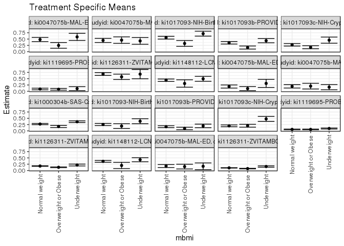

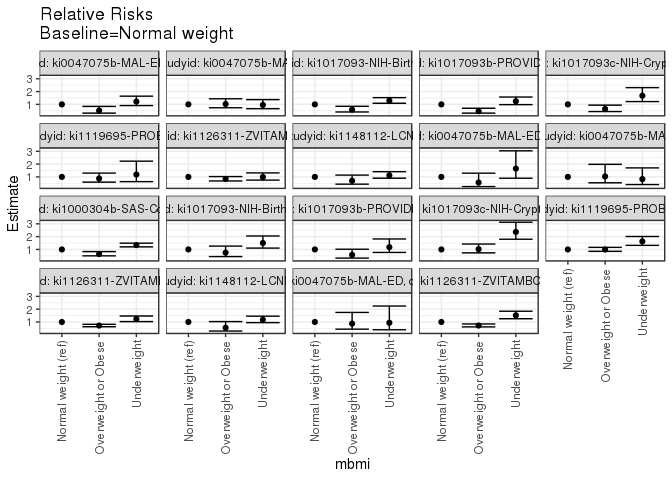

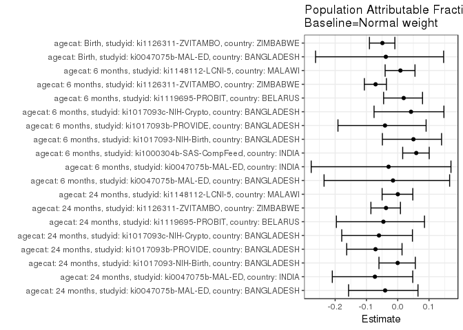

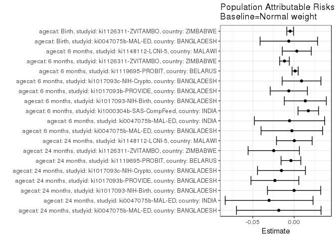

## Results Table

### Parameter: TSM

| agecat | studyid | country | intervention_level | baseline_level | estimate | ci_lower | ci_upper |
| --- | --- | --- | --- | --- | --- | --- | --- |
| Birth | ki0047075b-MAL-ED | BANGLADESH | Normal weight | NA | 0.1772152 | 0.1175532 | 0.2368772 |
| Birth | ki0047075b-MAL-ED | BANGLADESH | Underweight | NA | 0.1666667 | 0.0330361 | 0.3002972 |
| Birth | ki0047075b-MAL-ED | BANGLADESH | Overweight or Obese | NA | 0.1551724 | 0.0618019 | 0.2485430 |
| Birth | ki1126311-ZVITAMBO | ZIMBABWE | Normal weight | NA | 0.1040930 | 0.0967120 | 0.1114740 |
| Birth | ki1126311-ZVITAMBO | ZIMBABWE | Underweight | NA | 0.1580681 | 0.1299760 | 0.1861603 |
| Birth | ki1126311-ZVITAMBO | ZIMBABWE | Overweight or Obese | NA | 0.0751994 | 0.0647454 | 0.0856535 |
| 6 months | ki0047075b-MAL-ED | BANGLADESH | Normal weight | NA | 0.1895425 | 0.1273091 | 0.2517759 |
| 6 months | ki0047075b-MAL-ED | BANGLADESH | Underweight | NA | 0.3125000 | 0.1515699 | 0.4734301 |
| 6 months | ki0047075b-MAL-ED | BANGLADESH | Overweight or Obese | NA | 0.1071429 | 0.0259665 | 0.1883192 |
| 6 months | ki0047075b-MAL-ED | INDIA | Normal weight | NA | 0.1970803 | 0.1303272 | 0.2638334 |
| 6 months | ki0047075b-MAL-ED | INDIA | Underweight | NA | 0.1632653 | 0.0595562 | 0.2669744 |
| 6 months | ki0047075b-MAL-ED | INDIA | Overweight or Obese | NA | 0.2040816 | 0.0909947 | 0.3171685 |
| 6 months | ki1000304b-SAS-CompFeed | INDIA | Normal weight | NA | 0.2714278 | 0.2452884 | 0.2975673 |
| 6 months | ki1000304b-SAS-CompFeed | INDIA | Underweight | NA | 0.3631434 | 0.3279933 | 0.3982934 |
| 6 months | ki1000304b-SAS-CompFeed | INDIA | Overweight or Obese | NA | 0.1752218 | 0.1323084 | 0.2181353 |
| 6 months | ki1017093-NIH-Birth | BANGLADESH | Normal weight | NA | 0.2546827 | 0.2106173 | 0.2987482 |
| 6 months | ki1017093-NIH-Birth | BANGLADESH | Underweight | NA | 0.3834170 | 0.2847344 | 0.4820996 |
| 6 months | ki1017093-NIH-Birth | BANGLADESH | Overweight or Obese | NA | 0.1908143 | 0.0968059 | 0.2848227 |
| 6 months | ki1017093b-PROVIDE | BANGLADESH | Normal weight | NA | 0.1662890 | 0.1284743 | 0.2041038 |
| 6 months | ki1017093b-PROVIDE | BANGLADESH | Underweight | NA | 0.1963882 | 0.1244648 | 0.2683117 |
| 6 months | ki1017093b-PROVIDE | BANGLADESH | Overweight or Obese | NA | 0.0955451 | 0.0454611 | 0.1456290 |
| 6 months | ki1017093c-NIH-Crypto | BANGLADESH | Normal weight | NA | 0.2008792 | 0.1639239 | 0.2378345 |
| 6 months | ki1017093c-NIH-Crypto | BANGLADESH | Underweight | NA | 0.4759229 | 0.3779373 | 0.5739086 |
| 6 months | ki1017093c-NIH-Crypto | BANGLADESH | Overweight or Obese | NA | 0.2051230 | 0.1484885 | 0.2617576 |
| 6 months | ki1119695-PROBIT | BELARUS | Normal weight | NA | 0.0587332 | 0.0454765 | 0.0719900 |
| 6 months | ki1119695-PROBIT | BELARUS | Underweight | NA | 0.0956059 | 0.0757282 | 0.1154836 |
| 6 months | ki1119695-PROBIT | BELARUS | Overweight or Obese | NA | 0.0584638 | 0.0447059 | 0.0722218 |
| 6 months | ki1126311-ZVITAMBO | ZIMBABWE | Normal weight | NA | 0.1771307 | 0.1663916 | 0.1878699 |
| 6 months | ki1126311-ZVITAMBO | ZIMBABWE | Underweight | NA | 0.2177029 | 0.1814010 | 0.2540048 |
| 6 months | ki1126311-ZVITAMBO | ZIMBABWE | Overweight or Obese | NA | 0.1272721 | 0.1122308 | 0.1423134 |
| 6 months | ki1148112-LCNI-5 | MALAWI | Normal weight | NA | 0.3640553 | 0.3270716 | 0.4010390 |
| 6 months | ki1148112-LCNI-5 | MALAWI | Underweight | NA | 0.4275862 | 0.3470130 | 0.5081595 |
| 6 months | ki1148112-LCNI-5 | MALAWI | Overweight or Obese | NA | 0.2000000 | 0.0759668 | 0.3240332 |
| 24 months | ki0047075b-MAL-ED | BANGLADESH | Normal weight | NA | 0.4808791 | 0.3964904 | 0.5652678 |
| 24 months | ki0047075b-MAL-ED | BANGLADESH | Underweight | NA | 0.5860487 | 0.4440410 | 0.7280563 |
| 24 months | ki0047075b-MAL-ED | BANGLADESH | Overweight or Obese | NA | 0.2479550 | 0.1349274 | 0.3609826 |
| 24 months | ki0047075b-MAL-ED | INDIA | Normal weight | NA | 0.4462320 | 0.3631276 | 0.5293364 |
| 24 months | ki0047075b-MAL-ED | INDIA | Underweight | NA | 0.4263244 | 0.2933757 | 0.5592732 |
| 24 months | ki0047075b-MAL-ED | INDIA | Overweight or Obese | NA | 0.4585487 | 0.3306181 | 0.5864794 |
| 24 months | ki1017093-NIH-Birth | BANGLADESH | Normal weight | NA | 0.5548811 | 0.4980551 | 0.6117071 |
| 24 months | ki1017093-NIH-Birth | BANGLADESH | Underweight | NA | 0.7146388 | 0.6168418 | 0.8124358 |
| 24 months | ki1017093-NIH-Birth | BANGLADESH | Overweight or Obese | NA | 0.3261984 | 0.2111464 | 0.4412503 |
| 24 months | ki1017093b-PROVIDE | BANGLADESH | Normal weight | NA | 0.3514190 | 0.3028456 | 0.3999924 |
| 24 months | ki1017093b-PROVIDE | BANGLADESH | Underweight | NA | 0.4359680 | 0.3517008 | 0.5202352 |
| 24 months | ki1017093b-PROVIDE | BANGLADESH | Overweight or Obese | NA | 0.1647377 | 0.1036324 | 0.2258431 |
| 24 months | ki1017093c-NIH-Crypto | BANGLADESH | Normal weight | NA | 0.2721935 | 0.2238767 | 0.3205103 |
| 24 months | ki1017093c-NIH-Crypto | BANGLADESH | Underweight | NA | 0.4563422 | 0.3346699 | 0.5780145 |
| 24 months | ki1017093c-NIH-Crypto | BANGLADESH | Overweight or Obese | NA | 0.1746906 | 0.1155729 | 0.2338083 |
| 24 months | ki1119695-PROBIT | BELARUS | Normal weight | NA | 0.0893039 | 0.0565775 | 0.1220303 |
| 24 months | ki1119695-PROBIT | BELARUS | Underweight | NA | 0.1058730 | 0.0275599 | 0.1841862 |
| 24 months | ki1119695-PROBIT | BELARUS | Overweight or Obese | NA | 0.0782973 | 0.0433854 | 0.1132092 |
| 24 months | ki1126311-ZVITAMBO | ZIMBABWE | Normal weight | NA | 0.6851852 | 0.6297131 | 0.7406573 |
| 24 months | ki1126311-ZVITAMBO | ZIMBABWE | Underweight | NA | 0.6800000 | 0.4969017 | 0.8630983 |
| 24 months | ki1126311-ZVITAMBO | ZIMBABWE | Overweight or Obese | NA | 0.5731707 | 0.4659726 | 0.6803688 |
| 24 months | ki1148112-LCNI-5 | MALAWI | Normal weight | NA | 0.4400492 | 0.3942356 | 0.4858628 |
| 24 months | ki1148112-LCNI-5 | MALAWI | Underweight | NA | 0.4949114 | 0.3972889 | 0.5925339 |
| 24 months | ki1148112-LCNI-5 | MALAWI | Overweight or Obese | NA | 0.3097453 | 0.1631103 | 0.4563803 |

### Parameter: E(Y)

| agecat | studyid | country | intervention_level | baseline_level | estimate | ci_lower | ci_upper |
| --- | --- | --- | --- | --- | --- | --- | --- |
| Birth | ki0047075b-MAL-ED | BANGLADESH | NA | NA | 0.1707317 | 0.1236156 | 0.2178478 |
| Birth | ki1126311-ZVITAMBO | ZIMBABWE | NA | NA | 0.0992319 | 0.0932615 | 0.1052022 |
| 6 months | ki0047075b-MAL-ED | BANGLADESH | NA | NA | 0.1867220 | 0.1374205 | 0.2360234 |
| 6 months | ki0047075b-MAL-ED | INDIA | NA | NA | 0.1914894 | 0.1410749 | 0.2419038 |
| 6 months | ki1000304b-SAS-CompFeed | INDIA | NA | NA | 0.2885086 | 0.2628530 | 0.3141641 |
| 6 months | ki1017093-NIH-Birth | BANGLADESH | NA | NA | 0.2681564 | 0.2306532 | 0.3056597 |
| 6 months | ki1017093b-PROVIDE | BANGLADESH | NA | NA | 0.1597938 | 0.1299995 | 0.1895881 |
| 6 months | ki1017093c-NIH-Crypto | BANGLADESH | NA | NA | 0.2097902 | 0.1799252 | 0.2396552 |
| 6 months | ki1119695-PROBIT | BELARUS | NA | NA | 0.0598756 | 0.0470544 | 0.0726968 |
| 6 months | ki1126311-ZVITAMBO | ZIMBABWE | NA | NA | 0.1654241 | 0.1567862 | 0.1740620 |
| 6 months | ki1148112-LCNI-5 | MALAWI | NA | NA | 0.3672249 | 0.3345288 | 0.3999210 |
| 24 months | ki0047075b-MAL-ED | BANGLADESH | NA | NA | 0.4622642 | 0.3949918 | 0.5295365 |
| 24 months | ki0047075b-MAL-ED | INDIA | NA | NA | 0.4159292 | 0.3515272 | 0.4803312 |
| 24 months | ki1017093-NIH-Birth | BANGLADESH | NA | NA | 0.5547786 | 0.5076945 | 0.6018626 |
| 24 months | ki1017093b-PROVIDE | BANGLADESH | NA | NA | 0.3281250 | 0.2897474 | 0.3665026 |
| 24 months | ki1017093c-NIH-Crypto | BANGLADESH | NA | NA | 0.2568093 | 0.2190047 | 0.2946140 |
| 24 months | ki1119695-PROBIT | BELARUS | NA | NA | 0.0853933 | 0.0554084 | 0.1153781 |
| 24 months | ki1126311-ZVITAMBO | ZIMBABWE | NA | NA | 0.6604775 | 0.6126125 | 0.7083424 |
| 24 months | ki1148112-LCNI-5 | MALAWI | NA | NA | 0.4402080 | 0.3996684 | 0.4807475 |

### Parameter: RR

| agecat | studyid | country | intervention_level | baseline_level | estimate | ci_lower | ci_upper |
| --- | --- | --- | --- | --- | --- | --- | --- |
| Birth | ki0047075b-MAL-ED | BANGLADESH | Normal weight | Normal weight | 1.0000000 | 1.0000000 | 1.0000000 |
| Birth | ki0047075b-MAL-ED | BANGLADESH | Underweight | Normal weight | 0.9404762 | 0.3941728 | 2.2439285 |
| Birth | ki0047075b-MAL-ED | BANGLADESH | Overweight or Obese | Normal weight | 0.8756158 | 0.4394073 | 1.7448573 |
| Birth | ki1126311-ZVITAMBO | ZIMBABWE | Normal weight | Normal weight | 1.0000000 | 1.0000000 | 1.0000000 |
| Birth | ki1126311-ZVITAMBO | ZIMBABWE | Underweight | Normal weight | 1.5185278 | 1.2541200 | 1.8386811 |
| Birth | ki1126311-ZVITAMBO | ZIMBABWE | Overweight or Obese | Normal weight | 0.7224254 | 0.6180652 | 0.8444067 |
| 6 months | ki0047075b-MAL-ED | BANGLADESH | Normal weight | Normal weight | 1.0000000 | 1.0000000 | 1.0000000 |
| 6 months | ki0047075b-MAL-ED | BANGLADESH | Underweight | Normal weight | 1.6487069 | 0.8951628 | 3.0365812 |
| 6 months | ki0047075b-MAL-ED | BANGLADESH | Overweight or Obese | Normal weight | 0.5652709 | 0.2475405 | 1.2908239 |
| 6 months | ki0047075b-MAL-ED | INDIA | Normal weight | Normal weight | 1.0000000 | 1.0000000 | 1.0000000 |
| 6 months | ki0047075b-MAL-ED | INDIA | Underweight | Normal weight | 0.8284203 | 0.4032839 | 1.7017295 |
| 6 months | ki0047075b-MAL-ED | INDIA | Overweight or Obese | Normal weight | 1.0355253 | 0.5408912 | 1.9824922 |
| 6 months | ki1000304b-SAS-CompFeed | INDIA | Normal weight | Normal weight | 1.0000000 | 1.0000000 | 1.0000000 |
| 6 months | ki1000304b-SAS-CompFeed | INDIA | Underweight | Normal weight | 1.3379002 | 1.2010583 | 1.4903331 |
| 6 months | ki1000304b-SAS-CompFeed | INDIA | Overweight or Obese | Normal weight | 0.6455559 | 0.5013650 | 0.8312156 |
| 6 months | ki1017093-NIH-Birth | BANGLADESH | Normal weight | Normal weight | 1.0000000 | 1.0000000 | 1.0000000 |
| 6 months | ki1017093-NIH-Birth | BANGLADESH | Underweight | Normal weight | 1.5054693 | 1.1043956 | 2.0521973 |
| 6 months | ki1017093-NIH-Birth | BANGLADESH | Overweight or Obese | Normal weight | 0.7492236 | 0.4445342 | 1.2627512 |
| 6 months | ki1017093b-PROVIDE | BANGLADESH | Normal weight | Normal weight | 1.0000000 | 1.0000000 | 1.0000000 |
| 6 months | ki1017093b-PROVIDE | BANGLADESH | Underweight | Normal weight | 1.1810053 | 0.7676008 | 1.8170560 |
| 6 months | ki1017093b-PROVIDE | BANGLADESH | Overweight or Obese | Normal weight | 0.5745722 | 0.3243502 | 1.0178298 |
| 6 months | ki1017093c-NIH-Crypto | BANGLADESH | Normal weight | Normal weight | 1.0000000 | 1.0000000 | 1.0000000 |
| 6 months | ki1017093c-NIH-Crypto | BANGLADESH | Underweight | Normal weight | 2.3691993 | 1.7959088 | 3.1254958 |
| 6 months | ki1017093c-NIH-Crypto | BANGLADESH | Overweight or Obese | Normal weight | 1.0211261 | 0.7327760 | 1.4229430 |
| 6 months | ki1119695-PROBIT | BELARUS | Normal weight | Normal weight | 1.0000000 | 1.0000000 | 1.0000000 |
| 6 months | ki1119695-PROBIT | BELARUS | Underweight | Normal weight | 1.6277992 | 1.3184146 | 2.0097852 |
| 6 months | ki1119695-PROBIT | BELARUS | Overweight or Obese | Normal weight | 0.9954130 | 0.8530926 | 1.1614766 |
| 6 months | ki1126311-ZVITAMBO | ZIMBABWE | Normal weight | Normal weight | 1.0000000 | 1.0000000 | 1.0000000 |
| 6 months | ki1126311-ZVITAMBO | ZIMBABWE | Underweight | Normal weight | 1.2290523 | 1.0293074 | 1.4675592 |
| 6 months | ki1126311-ZVITAMBO | ZIMBABWE | Overweight or Obese | Normal weight | 0.7185210 | 0.6291857 | 0.8205407 |
| 6 months | ki1148112-LCNI-5 | MALAWI | Normal weight | Normal weight | 1.0000000 | 1.0000000 | 1.0000000 |
| 6 months | ki1148112-LCNI-5 | MALAWI | Underweight | Normal weight | 1.1745089 | 0.9481652 | 1.4548850 |
| 6 months | ki1148112-LCNI-5 | MALAWI | Overweight or Obese | Normal weight | 0.5493671 | 0.2930477 | 1.0298808 |
| 24 months | ki0047075b-MAL-ED | BANGLADESH | Normal weight | Normal weight | 1.0000000 | 1.0000000 | 1.0000000 |
| 24 months | ki0047075b-MAL-ED | BANGLADESH | Underweight | Normal weight | 1.2187028 | 0.9055701 | 1.6401121 |
| 24 months | ki0047075b-MAL-ED | BANGLADESH | Overweight or Obese | Normal weight | 0.5156286 | 0.3161072 | 0.8410844 |
| 24 months | ki0047075b-MAL-ED | INDIA | Normal weight | Normal weight | 1.0000000 | 1.0000000 | 1.0000000 |
| 24 months | ki0047075b-MAL-ED | INDIA | Underweight | Normal weight | 0.9553874 | 0.6650506 | 1.3724746 |
| 24 months | ki0047075b-MAL-ED | INDIA | Overweight or Obese | Normal weight | 1.0276017 | 0.7339926 | 1.4386593 |
| 24 months | ki1017093-NIH-Birth | BANGLADESH | Normal weight | Normal weight | 1.0000000 | 1.0000000 | 1.0000000 |
| 24 months | ki1017093-NIH-Birth | BANGLADESH | Underweight | Normal weight | 1.2879135 | 1.0857715 | 1.5276890 |
| 24 months | ki1017093-NIH-Birth | BANGLADESH | Overweight or Obese | Normal weight | 0.5878708 | 0.4072703 | 0.8485569 |
| 24 months | ki1017093b-PROVIDE | BANGLADESH | Normal weight | Normal weight | 1.0000000 | 1.0000000 | 1.0000000 |
| 24 months | ki1017093b-PROVIDE | BANGLADESH | Underweight | Normal weight | 1.2405933 | 0.9784599 | 1.5729533 |
| 24 months | ki1017093b-PROVIDE | BANGLADESH | Overweight or Obese | Normal weight | 0.4687787 | 0.3156256 | 0.6962474 |
| 24 months | ki1017093c-NIH-Crypto | BANGLADESH | Normal weight | Normal weight | 1.0000000 | 1.0000000 | 1.0000000 |
| 24 months | ki1017093c-NIH-Crypto | BANGLADESH | Underweight | Normal weight | 1.6765360 | 1.2174918 | 2.3086588 |
| 24 months | ki1017093c-NIH-Crypto | BANGLADESH | Overweight or Obese | Normal weight | 0.6417883 | 0.4379250 | 0.9405543 |
| 24 months | ki1119695-PROBIT | BELARUS | Normal weight | Normal weight | 1.0000000 | 1.0000000 | 1.0000000 |
| 24 months | ki1119695-PROBIT | BELARUS | Underweight | Normal weight | 1.1855367 | 0.6299674 | 2.2310634 |
| 24 months | ki1119695-PROBIT | BELARUS | Overweight or Obese | Normal weight | 0.8767510 | 0.5924273 | 1.2975302 |
| 24 months | ki1126311-ZVITAMBO | ZIMBABWE | Normal weight | Normal weight | 1.0000000 | 1.0000000 | 1.0000000 |
| 24 months | ki1126311-ZVITAMBO | ZIMBABWE | Underweight | Normal weight | 0.9924324 | 0.7491873 | 1.3146541 |
| 24 months | ki1126311-ZVITAMBO | ZIMBABWE | Overweight or Obese | Normal weight | 0.8365194 | 0.6822885 | 1.0256142 |
| 24 months | ki1148112-LCNI-5 | MALAWI | Normal weight | Normal weight | 1.0000000 | 1.0000000 | 1.0000000 |
| 24 months | ki1148112-LCNI-5 | MALAWI | Underweight | Normal weight | 1.1246728 | 0.8997924 | 1.4057565 |
| 24 months | ki1148112-LCNI-5 | MALAWI | Overweight or Obese | Normal weight | 0.7038879 | 0.4335117 | 1.1428944 |

### Parameter: PAR

| agecat | studyid | country | intervention_level | baseline_level | estimate | ci_lower | ci_upper |
| --- | --- | --- | --- | --- | --- | --- | --- |
| Birth | ki0047075b-MAL-ED | BANGLADESH | Normal weight | NA | -0.0064835 | -0.0412261 | 0.0282591 |
| Birth | ki1126311-ZVITAMBO | ZIMBABWE | Normal weight | NA | -0.0048611 | -0.0088954 | -0.0008269 |
| 6 months | ki0047075b-MAL-ED | BANGLADESH | Normal weight | NA | -0.0028205 | -0.0400502 | 0.0344092 |
| 6 months | ki0047075b-MAL-ED | INDIA | Normal weight | NA | -0.0055909 | -0.0480423 | 0.0368604 |
| 6 months | ki1000304b-SAS-CompFeed | INDIA | Normal weight | NA | 0.0170807 | 0.0046515 | 0.0295099 |
| 6 months | ki1017093-NIH-Birth | BANGLADESH | Normal weight | NA | 0.0134737 | -0.0118756 | 0.0388230 |
| 6 months | ki1017093b-PROVIDE | BANGLADESH | Normal weight | NA | -0.0064952 | -0.0289339 | 0.0159434 |
| 6 months | ki1017093c-NIH-Crypto | BANGLADESH | Normal weight | NA | 0.0089110 | -0.0144849 | 0.0323068 |
| 6 months | ki1119695-PROBIT | BELARUS | Normal weight | NA | 0.0011424 | -0.0025762 | 0.0048610 |
| 6 months | ki1126311-ZVITAMBO | ZIMBABWE | Normal weight | NA | -0.0117066 | -0.0175448 | -0.0058684 |
| 6 months | ki1148112-LCNI-5 | MALAWI | Normal weight | NA | 0.0031696 | -0.0143404 | 0.0206796 |
| 24 months | ki0047075b-MAL-ED | BANGLADESH | Normal weight | NA | -0.0186149 | -0.0697155 | 0.0324857 |
| 24 months | ki0047075b-MAL-ED | INDIA | Normal weight | NA | -0.0303028 | -0.0833853 | 0.0227797 |
| 24 months | ki1017093-NIH-Birth | BANGLADESH | Normal weight | NA | -0.0001025 | -0.0323032 | 0.0320981 |
| 24 months | ki1017093b-PROVIDE | BANGLADESH | Normal weight | NA | -0.0232940 | -0.0522135 | 0.0056255 |
| 24 months | ki1017093c-NIH-Crypto | BANGLADESH | Normal weight | NA | -0.0153841 | -0.0443222 | 0.0135539 |
| 24 months | ki1119695-PROBIT | BELARUS | Normal weight | NA | -0.0039106 | -0.0158725 | 0.0080512 |
| 24 months | ki1126311-ZVITAMBO | ZIMBABWE | Normal weight | NA | -0.0247077 | -0.0557015 | 0.0062860 |
| 24 months | ki1148112-LCNI-5 | MALAWI | Normal weight | NA | 0.0001588 | -0.0214161 | 0.0217337 |

### Parameter: PAF

| agecat | studyid | country | intervention_level | baseline_level | estimate | ci_lower | ci_upper |
| --- | --- | --- | --- | --- | --- | --- | --- |
| Birth | ki0047075b-MAL-ED | BANGLADESH | Normal weight | NA | -0.0379747 | -0.2625963 | 0.1466857 |
| Birth | ki1126311-ZVITAMBO | ZIMBABWE | Normal weight | NA | -0.0489875 | -0.0903885 | -0.0091585 |
| 6 months | ki0047075b-MAL-ED | BANGLADESH | Normal weight | NA | -0.0151053 | -0.2353941 | 0.1659028 |
| 6 months | ki0047075b-MAL-ED | INDIA | Normal weight | NA | -0.0291971 | -0.2764898 | 0.1701879 |
| 6 months | ki1000304b-SAS-CompFeed | INDIA | Normal weight | NA | 0.0592035 | 0.0159094 | 0.1005930 |
| 6 months | ki1017093-NIH-Birth | BANGLADESH | Normal weight | NA | 0.0502456 | -0.0490008 | 0.1401023 |
| 6 months | ki1017093b-PROVIDE | BANGLADESH | Normal weight | NA | -0.0406475 | -0.1909677 | 0.0906998 |
| 6 months | ki1017093c-NIH-Crypto | BANGLADESH | Normal weight | NA | 0.0424757 | -0.0756247 | 0.1476090 |
| 6 months | ki1119695-PROBIT | BELARUS | Normal weight | NA | 0.0190798 | -0.0450639 | 0.0792865 |
| 6 months | ki1126311-ZVITAMBO | ZIMBABWE | Normal weight | NA | -0.0707672 | -0.1065964 | -0.0360981 |
| 6 months | ki1148112-LCNI-5 | MALAWI | Normal weight | NA | 0.0086312 | -0.0402171 | 0.0551856 |
| 24 months | ki0047075b-MAL-ED | BANGLADESH | Normal weight | NA | -0.0402690 | -0.1570875 | 0.0647556 |
| 24 months | ki0047075b-MAL-ED | INDIA | Normal weight | NA | -0.0728556 | -0.2090504 | 0.0479974 |
| 24 months | ki1017093-NIH-Birth | BANGLADESH | Normal weight | NA | -0.0001848 | -0.0599445 | 0.0562056 |
| 24 months | ki1017093b-PROVIDE | BANGLADESH | Normal weight | NA | -0.0709912 | -0.1630755 | 0.0138026 |
| 24 months | ki1017093c-NIH-Crypto | BANGLADESH | Normal weight | NA | -0.0599049 | -0.1788751 | 0.0470590 |
| 24 months | ki1119695-PROBIT | BELARUS | Normal weight | NA | -0.0457957 | -0.1960057 | 0.0855491 |
| 24 months | ki1126311-ZVITAMBO | ZIMBABWE | Normal weight | NA | -0.0374089 | -0.0856609 | 0.0086985 |
| 24 months | ki1148112-LCNI-5 | MALAWI | Normal weight | NA | 0.0003607 | -0.0498712 | 0.0481891 |